# PulmonDB - COVID19.

Regulons Selection: tissues

Monica Padilla

2022-10-19

```r
## Load functions
source("~/Documents/RegGenoLab/COVID19/pyscenic/regulons-selection-scripts/regs-analysis.R")
```

[output not shown]

[output not shown]

[output not shown]

## **Selection of Regulons based on Differentially Activation and Specificity**

Use of Regulon Specificity Scores (also referred here as enrichment although it is not exactly) + Differential Activation (DA) of Regulons Analysis. This is an exploratory report on the parameters used to select regulons. Main code for Regulons Selection = `reticulateEnrich.R`

### **DA tests pvalues distributions**

#### **Mann Whitney U Test**

*P-values* distributions resulting from `Mann Whitney U Test` for Differential Activation of Regulons (measured from AUC scores per regulon, Regulon Activity Matrix). Non-adjusted *p-values* are displayed.

Run `reticulateEnrich_.R` first.

```r
library(tidyverse) ## gplot, dplyr, stringr
library(ggpubr) ## ggarange

pvalues <- as.data.frame(read_csv(paste0(params$inputdir, params$pval_mwu.fn), col_names = T))
plots <- vector('list', length(pvalues)) # list of plots
# create plots iteratively
for (i in 1:ncol(pvalues)) {
  exp <- colnames(pvalues)[i]
  print(exp)

  plots[[i]] <- ggplot(pvalues,aes(x=.data[[exp]])) + #<<
    geom_bar(fill="#9966bb") + # geom hist didnt work
    scale_x_binned() +
    labs(title = exp, x="pvalue", y="")
}
```

```
## [1] "Bowel"
## [1] "Heart"
## [1] "Kidney"
## [1] "Liver"
## [1] "Lung"
```

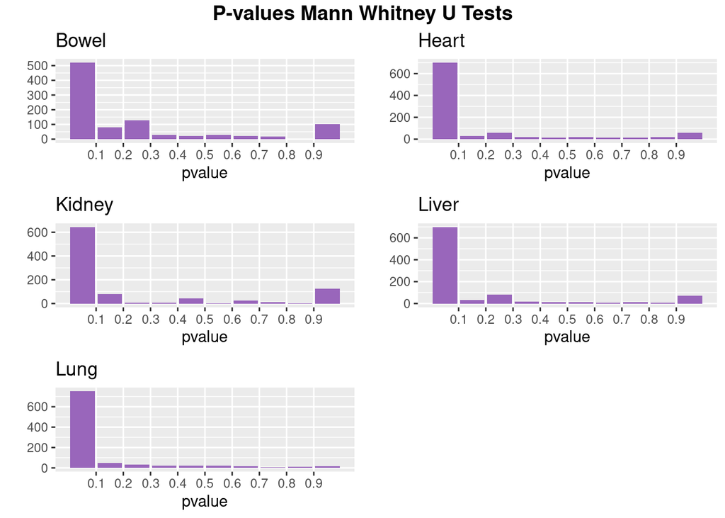

```r
names(plots) <- names(pvalues)

# display plots together
p <- ggarrange(plots[[1]],plots[[2]],plots[[3]],plots[[4]],plots[[5]],
          ncol = 2, nrow = 3)
# add title
annotate_figure(p,
                top = text_grob("P-values Mann Whitney U Tests",face = "bold", size = 14))
```

```r
png(paste0(params$outdir,"hist_pvalues-mwu.png"))
# add title
annotate_figure(p,
                top = text_grob("P-values Mann Whitney U Tests",face = "bold", size = 14))
dev.off()
```

```r
# minimum p values per experiment
apply(pvalues,2,min)
```

```
##        Bowel        Heart       Kidney        Liver         Lung
## 1.733589e-03 5.019215e-05 2.830068e-03 2.329425e-04 3.592480e-15
```

Each pvalue corresponds to a TF/regulon being differentially active in a given experiment vs its control (not shown).

- pvalues from **TRUE** null hypothesis (corresponding to Error Type II) distribution –> **uniform distribution** in range [0,1]
- pvalues from **FALSE** null hypothesis distribution –> asymetric, skewed to zero

Most of these distributions show that pvalues are more skewed to zero than what we would expect from a uniform distribution thus indicating that most of them correspond to **FALSE** null hypothesis.

Using a too low significance level would lead to rejecting true positives.[1]

#### **Kolmogrov Test**

*P-values* distributions resulting from `Kolmogrov Test` for Differential Activation of Regulons (measured from AUC scores per regulon, Regulon Activity Matrix). Non-adjusted *p-values* are displayed.

```r
library(tidyverse) ## gplot, dplyr, stringr
library(ggpubr) ## ggarange


pvalues2 <- as.data.frame(read_csv(paste0(params$inputdir,params$pval_klm.fn), col_names = T))
# rename cols for display in graphs
names(pvalues2) <- names(pvalues)

plots2 <- vector('list', length(pvalues2)) # list of plots
# create plots iteratively
for (i in 1:ncol(pvalues2)) {
  exp <- colnames(pvalues2)[i]
  print(exp)

  plots2[[i]] <- ggplot(pvalues2,aes(x=.data[[exp]])) + #<<
    geom_bar(fill="#9966bb") + # geom hist didnt work
    scale_x_binned() +
    labs(title = exp, x="pvalue", y="")

}
```

```
## [1] "Bowel"
## [1] "Heart"
## [1] "Kidney"
## [1] "Liver"
## [1] "Lung"
```

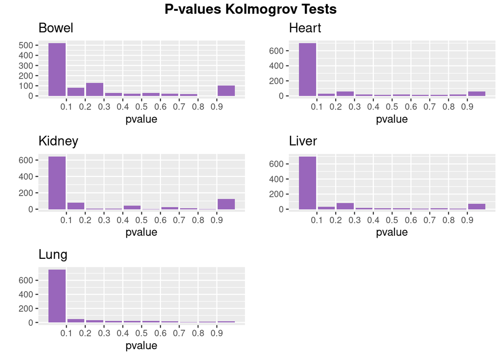

```r
names(plots2) <- names(pvalues2)

# display plots together
p <- ggarrange(plots[[1]],plots[[2]],plots[[3]],plots[[4]],plots[[5]],
          ncol = 2, nrow = 3)
# add title
annotate_figure(p,
                top = text_grob("P-values Kolmogrov Tests",face = "bold", size = 14))
```

```r
png(paste0(params$outdir,"hist_pvalues-klm.png"), width = 600, height = 600)
annotate_figure(p,
                top = text_grob("P-values Kolmogrov Tests",face = "bold", size = 14))
dev.off()
```

```r
apply(pvalues,2,min)
```

```
##        Bowel        Heart       Kidney        Liver         Lung
## 1.733589e-03 5.019215e-05 2.830068e-03 2.329425e-04 3.592480e-15
```

### **DA tests adjusted pvalues distributions**

#### **Mann Whitney U Test**

Get dataframes of adjusted pvalues from both test to work with locally:

```r
# on the cluster
# Run `reticulateEnrich_.R` first
library(tidyverse)

# retrieve adjusted pvalues from difregs script
pvalues_adj <- py$pvalues_adjusted
pvalues_adj2 <- py$pvalues_adjusted2


# turn to dataframes
pv.adj.mwu <- t(data.frame(matrix(unlist(pvalues_adj), nrow=length(pvalues_adj), byrow=TRUE)))
colnames(pv.adj.mwu) <- keys_ct
pv.adj.klm <- t(data.frame(matrix(unlist(pvalues_adj2), nrow=length(pvalues_adj2), byrow=TRUE)))
colnames(pv.adj.klm) <- keys_ct
write.csv(pv.adj.mwu, file = paste0(outdir,"pvalues-mwu-2t-adjusted.csv"), quote = F, row.names = F)
write.csv(pv.adj.mwu, file = paste0(outdir,"pvalues-klm-2t-adjusted.csv"), quote = F, row.names = F)
```

Make plots:

```r
library(tidyverse) ## gplot, dplyr, stringr
library(ggpubr) ## ggarange

pv.adj.mwu <- as.data.frame(
  read_csv(file = paste0(params$inputdir,params$adj_pvals_mwu.fn),col_names = T))
pvalues <- pv.adj.mwu # just changed this #<<

plots <- vector('list', length(pvalues)) # list of plots
# create plots iteratively
for (i in 1:ncol(pvalues)) {
  exp <- colnames(pvalues)[i]
  print(exp)

  plots[[i]] <- ggplot(pvalues,aes(x=.data[[exp]])) + #<<
    geom_bar(fill="#9966bb") + # geom hist didnt work
    scale_x_binned() +
    labs(title = exp, x="pvalue", y="")

}
```

```
## [1] "Bowel"
## [1] "Heart"
## [1] "Kidney"
## [1] "Liver"
## [1] "Lung"
```

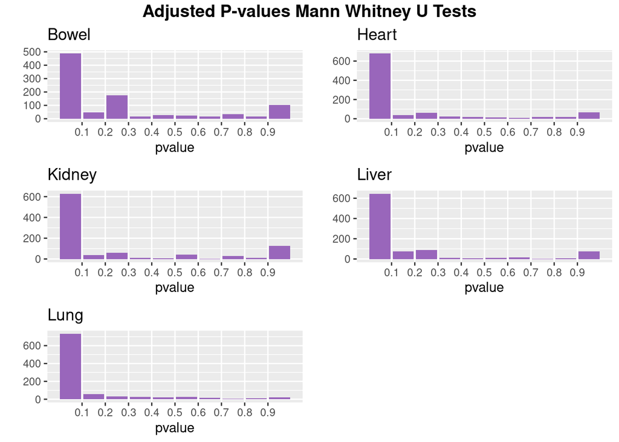

```r
names(plots) <- names(pvalues)


# display plots together
p <- ggarrange(plots[[1]],plots[[2]],plots[[3]],plots[[4]],plots[[5]],
          ncol = 2, nrow = 3)
annotate_figure(p,top = text_grob("Adjusted P-values Mann Whitney U Tests",face = "bold", size = 14)) # and this
```

```r
png(paste0(params$outdir,"hist_adj-pvalues-mwu.png"), width = 600, height = 600)
annotate_figure(p,top = text_grob("Adjusted P-values Mann Whitney U Tests",face = "bold", size = 14)) # and this
dev.off()
```

```r
# minimum p values per experiment
apply(pvalues,2,min)
```

```
##        Bowel        Heart       Kidney        Liver         Lung
## 2.424664e-02 1.067048e-03 2.881800e-02 3.588664e-03 8.505196e-13
```

#### **Kolmogrov Test**

```r
library(tidyverse) ## gplot, dplyr, stringr
library(ggpubr) ## ggarange

pv.adj.klm <- as.data.frame(read_csv(paste0(params$inputdir,params$adj_pvals_klm.fn), col_names = T))
pvalues2 <- pv.adj.klm # just changed this #<<

# rename cols for display in graphs
names(pvalues2) <- names(pvalues)

plots2 <- vector('list', length(pvalues2)) # list of plots
# create plots iteratively
for (i in 1:ncol(pvalues2)) {
  exp <- colnames(pvalues2)[i]
  print(exp)

  plots2[[i]] <- ggplot(pvalues2,aes(x=.data[[exp]])) + #<<
    geom_bar(fill="#9966bb") + # geom hist didnt work
    scale_x_binned() +
    labs(title = exp, x="pvalue", y="")

}
```

```
## [1] "Bowel"
## [1] "Heart"
## [1] "Kidney"
## [1] "Liver"
## [1] "Lung"
```

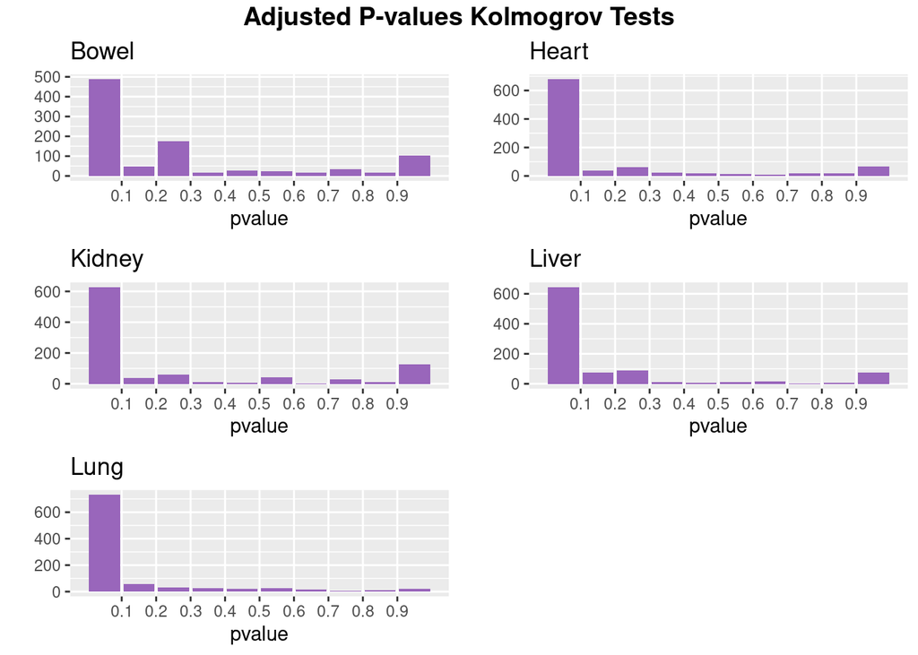

```r
names(plots2) <- names(pvalues2)

# display plots together
p <- ggarrange(plots[[1]],plots[[2]],plots[[3]],plots[[4]],plots[[5]],
          ncol = 2, nrow = 3)
# add title
annotate_figure(p,
                top = text_grob("Adjusted P-values Kolmogrov Tests",
                                face = "bold", size = 14)) # and this
```

```r
png(paste0(params$outdir,"hist_adj-pvalues-klm.png"), width = 600, height = 600)
annotate_figure(p,
                top = text_grob("Adjusted P-values Kolmogrov Tests",
                                face = "bold", size = 14)) # and this
dev.off()
```

```r
apply(pvalues,2,min)
```

```
##        Bowel        Heart       Kidney        Liver         Lung
## 2.424664e-02 1.067048e-03 2.881800e-02 3.588664e-03 8.505196e-13
```

### **FDR threshold on adjusted p-values**

#### **Mann Whitney U Test**

Import dataset and call source script with functions:

```r
library(tidyverse)

## call functios
source("~/Documents/RegGenoLab/COVID19/PulmonDB_COVID/COVID/bulk/rScripts/FDRthreshold_functions.R")

## dataset
pv.adj.mwu <- as.data.frame(read_csv(paste0(params$inputdir,params$adj_pvals_mwu.fn), col_names = T))
pv.adj.mwu <- as.data.frame(pv.adj.mwu)
# rename cols for display in graph
#head(pv.adj.mwu)
```

```r
thrs.mwu <- regsPerFDRthr(pv.adj.mwu, fdr_lowth = 0.0005, step = 0.001, fdr_upthr = 0.03)
thrs.mwu
```

|  | FDR_5e-04 | FDR_0.0015 | FDR_0.0025 | FDR_0.0035 | FDR_0.0045 | FDR_0.0055 | FDR_0.0065 | FDR_0.0075 | FDR_0.0085 | FDR_0.0095 | FDR_0.0105 | FDR_0.0115 | FDR_0.0125 | FDR_0.0135 | FDR_0.0145 | FDR_0.0155 | FDR_0.0165 | FDR_0.0175 | FDR_0.0185 | FDR_0.0195 | FDR_0.0205 | FDR_0.0215 | FDR_0.0225 | FDR_0.0235 | FDR_0.0245 | FDR_0.0255 | FDR_0.0265 | FDR_0.0275 | FDR_0.0285 | … |
| --- | --- | --- | --- | --- | --- | --- | --- | --- | --- | --- | --- | --- | --- | --- | --- | --- | --- | --- | --- | --- | --- | --- | --- | --- | --- | --- | --- | --- | --- | --- |
| Bowel | 0 | 0 | 0 | 0 | 0 | 0 | 0 | 0 | 0 | 0 | 0 | 0 | 0 | 0 | 0 | 0 | 0 | 0 | 0 | 0 | 0 | 0 | 0 | 0 | 331 | 331 | 331 | 371 | 371 | … |
| Heart | 0 | 339 | 368 | 414 | 416 | 427 | 435 | 437 | 443 | 443 | 447 | 463 | 475 | 477 | 482 | 487 | 489 | 490 | 491 | 503 | 504 | 506 | 507 | 527 | 527 | 527 | 527 | 530 | 537 | … |
| Kidney | 0 | 0 | 0 | 0 | 0 | 0 | 0 | 0 | 0 | 0 | 0 | 0 | 0 | 0 | 0 | 0 | 0 | 0 | 0 | 0 | 0 | 0 | 0 | 0 | 0 | 0 | 0 | 0 | 0 | … |
| Liver | 0 | 0 | 0 | 0 | 366 | 378 | 379 | 392 | 392 | 392 | 399 | 399 | 439 | 439 | 443 | 444 | 458 | 458 | 458 | 458 | 458 | 458 | 467 | 467 | 467 | 467 | 467 | 467 | 467 | … |
| Lung | 514 | 549 | 564 | 575 | 586 | 591 | 598 | 604 | 608 | 615 | 619 | 620 | 623 | 624 | 625 | 630 | 632 | 632 | 639 | 640 | 640 | 640 | 643 | 650 | 650 | 652 | 653 | 653 | 664 | … |

```r
# ALSO TRY
# thrs.mwu <- regsPerFDRthr(pv.adj.mwu, fdr_lowth = 0.05)
# thrs.mwu
```

El `FDR threshold` elegido por experimento se especifica aquí:

```r
fdrs.mwu <- getChosenFDRth(thrs.mwu, min.regs = c(100,93))
fdrs.mwu
```

|  | chosen | FDR_thr | nregulons |
| --- | --- | --- | --- |
| Lung | 1 | 0.0005 | 514 |
| Heart | 2 | 0.0015 | 339 |
| Liver | 5 | 0.0045 | 366 |
| Bowel | 25 | 0.0245 | 331 |
| Kidney | 30 | 0.0295 | 93 |

```r
# ALSO TRY
```

#### **Kolmogrov Test**

```r
thrs.klm <- regsPerFDRthr(pv.adj.mwu, fdr_lowth = 0.0005, step = 0.001, fdr_upthr = 0.03)
thrs.klm
```

|  | FDR_5e-04 | FDR_0.0015 | FDR_0.0025 | FDR_0.0035 | FDR_0.0045 | FDR_0.0055 | FDR_0.0065 | FDR_0.0075 | FDR_0.0085 | FDR_0.0095 | FDR_0.0105 | FDR_0.0115 | FDR_0.0125 | FDR_0.0135 | FDR_0.0145 | FDR_0.0155 | FDR_0.0165 | FDR_0.0175 | FDR_0.0185 | FDR_0.0195 | FDR_0.0205 | FDR_0.0215 | FDR_0.0225 | FDR_0.0235 | FDR_0.0245 | FDR_0.0255 | FDR_0.0265 | FDR_0.0275 | FDR_0.0285 | … |
| --- | --- | --- | --- | --- | --- | --- | --- | --- | --- | --- | --- | --- | --- | --- | --- | --- | --- | --- | --- | --- | --- | --- | --- | --- | --- | --- | --- | --- | --- | --- |
| Bowel | 0 | 0 | 0 | 0 | 0 | 0 | 0 | 0 | 0 | 0 | 0 | 0 | 0 | 0 | 0 | 0 | 0 | 0 | 0 | 0 | 0 | 0 | 0 | 0 | 331 | 331 | 331 | 371 | 371 | … |
| Heart | 0 | 339 | 368 | 414 | 416 | 427 | 435 | 437 | 443 | 443 | 447 | 463 | 475 | 477 | 482 | 487 | 489 | 490 | 491 | 503 | 504 | 506 | 507 | 527 | 527 | 527 | 527 | 530 | 537 | … |
| Kidney | 0 | 0 | 0 | 0 | 0 | 0 | 0 | 0 | 0 | 0 | 0 | 0 | 0 | 0 | 0 | 0 | 0 | 0 | 0 | 0 | 0 | 0 | 0 | 0 | 0 | 0 | 0 | 0 | 0 | … |
| Liver | 0 | 0 | 0 | 0 | 366 | 378 | 379 | 392 | 392 | 392 | 399 | 399 | 439 | 439 | 443 | 444 | 458 | 458 | 458 | 458 | 458 | 458 | 467 | 467 | 467 | 467 | 467 | 467 | 467 | … |
| Lung | 514 | 549 | 564 | 575 | 586 | 591 | 598 | 604 | 608 | 615 | 619 | 620 | 623 | 624 | 625 | 630 | 632 | 632 | 639 | 640 | 640 | 640 | 643 | 650 | 650 | 652 | 653 | 653 | 664 | … |

El `FDR threshold` elegido por experimento se especifica aquí:

```r
fdrs.klm <- getChosenFDRth(thrs.klm, min.regs = c(100,30))
fdrs.klm
```

|  | chosen | FDR_thr | nregulons |
| --- | --- | --- | --- |
| Lung | 1 | 0.0005 | 514 |
| Heart | 2 | 0.0015 | 339 |
| Liver | 5 | 0.0045 | 366 |
| Bowel | 25 | 0.0245 | 331 |
| Kidney | 30 | 0.0295 | 93 |

### **Regulons Counts After Filtering**

#### **DA:**

After taking common Differentialy Activated Regulons from both tests:

```r
tfs_da.fn <- paste0(params$inputdir, params$tfs_DA_2t.fn)
tfs_da <- readRDS(tfs_da.fn)
# at reticulateEnrich line 117
## check how many regulons were kept
t(as.data.frame(lapply(tfs_da,length)))
```

```
##        [,1]
## Bowel   330
## Heart   313
## Kidney   93
## Liver   333
## Lung    510
```

✅ Filter Applied

Differentiate between **Up** and **Down Regulated** regulons based on logFC (infection/mock):

```r
library(tidyverse)

## Load Data
# auc_mtx
auc_mtx <- readRDS(paste0(params$inputdir,params$auc_mtx))

# Load data: TFs names (in order after just scenic counts cutoff)
tfs <- as.data.frame(read_csv(paste0(params$inputdir,params$tfs.fn), col_names = F))[,1]
tfs <- stringr::str_remove(tfs, "_\\(\\+\\)")
tfs <- tfs[match(str_remove(colnames(auc_mtx),"_\\(\\+\\)"), tfs)]

# Load and tidy data: log 2 FC (auc_mtx)
l2fc <- as.data.frame(read_csv(paste0(params$inputdir,params$l2fc.fn), col_names = T))
rownames(l2fc) <- colnames(auc_mtx)
head(l2fc)
```

|  | Bowel | Heart | Kidney | Liver | Lung |
| --- | --- | --- | --- | --- | --- |
| A1CF_(+) | 0.04016219 | 0.043604575 | 0.03742717 | 0.0439626368 | 0.023396689 |
| ACAA1_(+) | 0.01355464 | -0.001592397 | 0.02197616 | 0.0271970576 | 0.003469151 |
| AHCTF1_(+) | -0.43496161 | -0.412323436 | -0.21021404 | -0.2294636930 | -0.589333080 |
| AHR_(+) | -0.02003082 | -0.005907004 | -0.03956332 | -0.0055455088 | 0.012740955 |
| AIRE_(+) | 0.00000000 | 0.000000000 | 0.00000000 | 0.0002550959 | 0.002508352 |
| AKR1A1_(+) | -0.07750677 | -0.061592554 | -0.15176687 | -0.1609256814 | -0.077864841 |

```r
## match dfs rows (tfs)
l2fc <- l2fc[match(str_replace(tfs,"$","_\\(\\+\\)"),rownames(l2fc)),]

## Make lists of up/down regulons
tfs_da_up = list()
tfs_da_down = list()
for (exp in names(tfs_da)) {
  tfs_da_up[[exp]] <- tfs_da[[exp]][tfs_da[[exp]] %in%  rownames(l2fc)[which(l2fc[exp] > 0)]]
  tfs_da_down[[exp]] <- tfs_da[[exp]][tfs_da[[exp]] %in% rownames(l2fc)[which(l2fc[exp] < 0)]]
}

# make df of counts of regulons
n_up <- t(as.data.frame(lapply(tfs_da_up,length)))[,1]
n_down <- t(as.data.frame(lapply(tfs_da_down,length)))[,1]
data.frame(up = n_up, down = n_down)
```

|  | up | down |
| --- | --- | --- |
| Bowel | 206 | 124 |
| Heart | 197 | 116 |
| Kidney | 93 | 0 |
| Liver | 218 | 115 |
| Lung | 344 | 166 |

✅ Filter Applied for **Upregulated** Regulons

#### **DA + specificity:**

After filtering regulons for those that had an optimal `LFC enrichment` :

```r
tfs_da_enrich.fn <- paste0(params$inputdir, params$tfs_DA_enrichLFC_2t.fn)
tfs_da_enrich <- readRDS(tfs_da_enrich.fn)
names(tfs_da_enrich) <- names(tfs_da)
# at reticulateEnrich line 117
## check how many regulons were kept
t(as.data.frame(lapply(tfs_da_enrich,length)))
```

```
##        [,1]
## Bowel   206
## Heart   199
## Kidney   82
## Liver   219
## Lung    380
```

Differentiate between **Up** and **Down Regulated** regulons again:

```r
## Make lists of up/down regulons
tfs_da_enrich_up = list()
tfs_da_enrich_down = list()
for (exp in names(tfs_da_enrich)) {
  tfs_da_enrich_up[[exp]] <-
    tfs_da_enrich[[exp]][tfs_da_enrich[[exp]] %in% rownames(l2fc)[which(l2fc[exp] > 0)]]
  tfs_da_enrich_down[[exp]] <-
    tfs_da_enrich[[exp]][tfs_da_enrich[[exp]] %in% rownames(l2fc)[which(l2fc[exp] < 0)]]
}

# make df of counts of regulons
n_up <- t(as.data.frame(lapply(tfs_da_enrich_up,length)))[,1]
n_down <- t(as.data.frame(lapply(tfs_da_enrich_down,length)))[,1]
data.frame(up = n_up, down = n_down)
```

|  | up | down |
| --- | --- | --- |
| Bowel | 193 | 13 |
| Heart | 184 | 15 |
| Kidney | 82 | 0 |
| Liver | 208 | 11 |
| Lung | 336 | 44 |

For regulons that were `Upregulated` and enriched, this filter keeps a decent number of regulons, but that’s not the case for `Downregulated` regulons.

✅ Filter Applied for **Upregulated** Regulons

### **Volcano Plots**

```r
library(ggplot2)
library(ggrepel)

############################################
## Plots 2t - 2 tails test

# Load and tidy data: regulons/tfs that were in DA + enriched
paste0("using set of DA regulons (tfs): ",tfs_da.fn)
```

```
## [1] "using set of DA regulons (tfs): ../regulons-analysis/out/organs-desgtex2/tfs_mwu_ks_fdr0005-0295-2t.RData"
```

```r
tfs_da.fn <- paste0(params$inputdir, params$tfs_DA_2t.fn)
tfs_da <- readRDS(tfs_da.fn)
dfs <- list2Dfs(tfs_da)
dfs$Bowel
```

| Bowel |
| --- |
| AHCTF1 |
| AR |
| ARID3C |
| ARID5A |
| ARNT |
| ARNT2 |
| ARNTL2 |
| ARX |
| ATF3 |
| ATF7 |

[output cut: 320 more lines]

```r
dfs$Heart
```

| Heart |
| --- |
| AHCTF1 |
| AKR1A1 |
| AR |
| ARID3C |
| ARNT |
| ARNT2 |
| ATF1 |
| ATF3 |
| BACH1 |
| BATF3 |

[output cut: 303 more lines]

```r
dfs$Kidney
```

| Kidney |
| --- |
| ARID3C |
| BARHL1 |
| BATF3 |
| BCL11B |
| BDP1 |
| BHLHE22 |
| CSNK2B |
| ENO1 |
| EZR |
| FOXC2 |

[output cut: 83 more lines]

```r
dfs$Liver
```

| Liver |
| --- |
| AHCTF1 |
| AHR |
| AKR1A1 |
| AR |
| ARID3C |
| ARID5A |
| ARNT |
| ARNTL2 |
| ARX |
| ATF1 |

[output cut: 323 more lines]

```r
dfs$Lung
```

| Lung |
| --- |
| AHCTF1 |
| AKR1A1 |
| ALX3 |
| AR |
| ARID3A |
| ARID3C |
| ARID5A |
| ARNT |
| ARNT2 |
| ARNTL |

[output cut: 500 more lines]

```r
# Load and tidy data: adjusted pvalues, format
paste0("using pvalues from test : ", params$adj_pvals_mwu.fn)
```

```
## [1] "using pvalues from test : pvalues-mwu-2t-adjusted.csv"
```

```r
pvalues <- as.data.frame(read_csv(paste0(params$inputdir,params$adj_pvals_mwu.fn), col_names = T))
rownames(pvalues) <- tfs

## Graph a Volcano Plot per condition
plots <- volcanos_per_exp(pvalues = pvalues, tfs_da = tfs_da,
                          test = "2t", save_png=T, outdir = params$outdir)
```

```
## [1] "Bowel"
```

```
## [1] "Heart"
```

```
## [1] "Kidney"
```

```
## [1] "Liver"
```

```
## [1] "Lung"
```

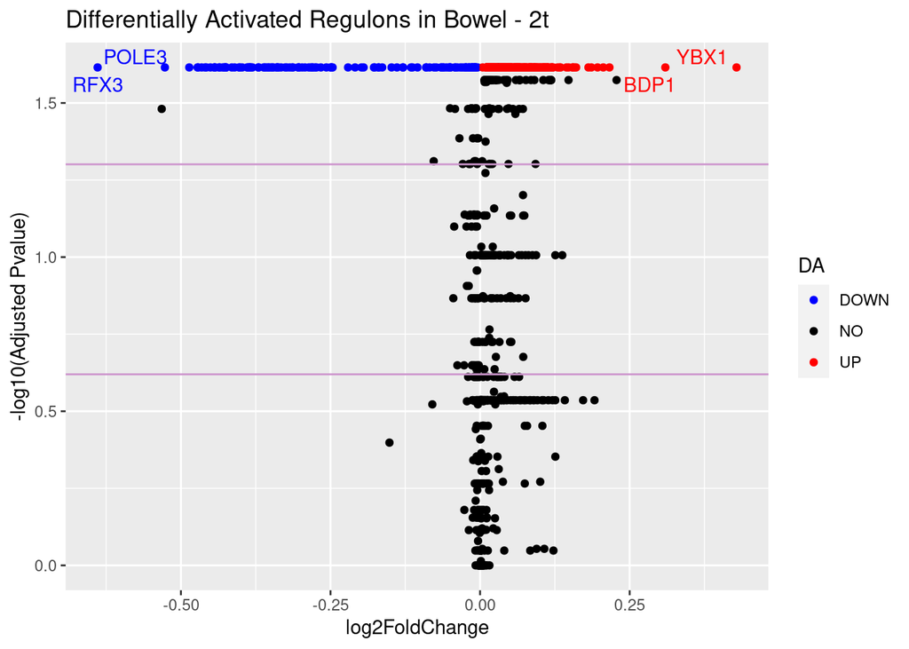

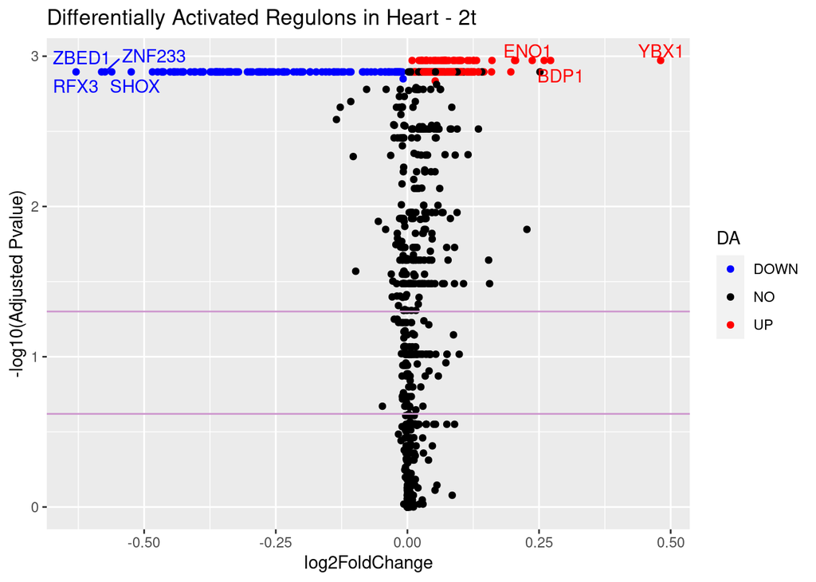

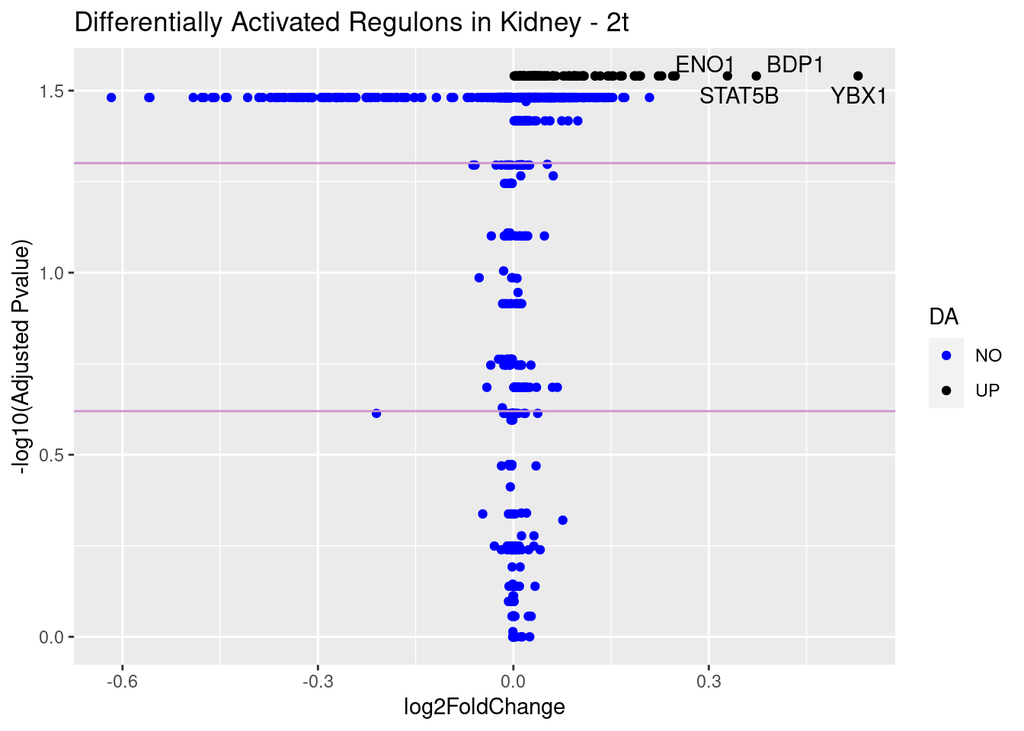

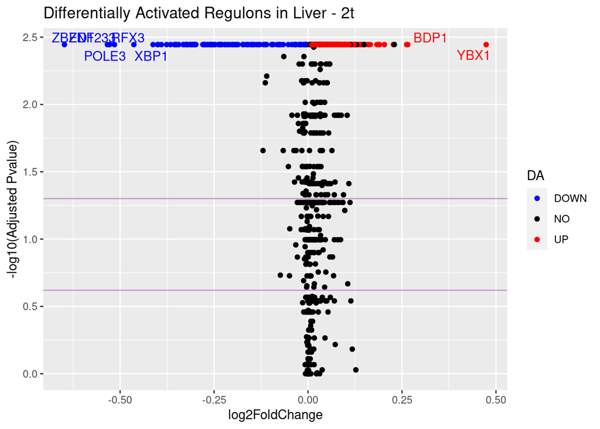

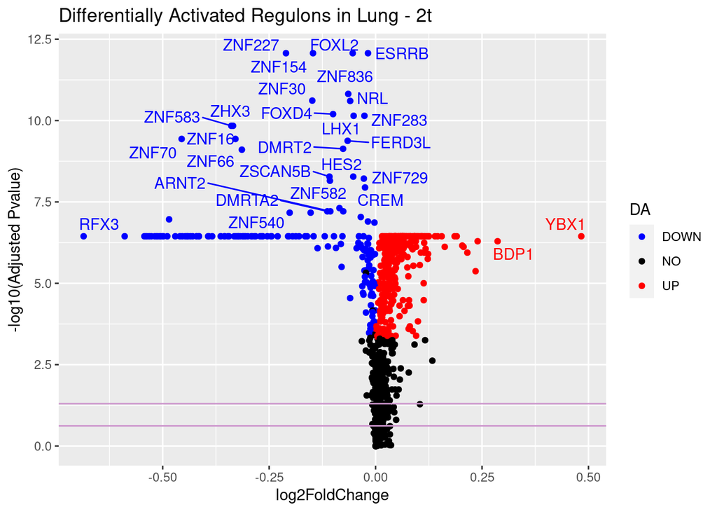

```r
plots
```

```r
############################################
## Make lists of up/down regulons
tfs_da_up = list()
tfs_da_down = list()
for (exp in names(tfs_da)) {
  tfs_da_up[[exp]] <- tfs_da[[exp]][tfs_da[[exp]] %in%  rownames(l2fc[exp] > 0)]
  tfs_da_down[[exp]] <- tfs_da[[exp]][tfs_da[[exp]] %in% rownames(l2fc[exp] > 0)]
}
```

```r
#tfs_da_up
dfs <- list2Dfs(tfs_da_up)
dfs$Bowel
```

| Bowel |
| --- |
| AHCTF1 |
| AR |
| ARID3C |
| ARID5A |
| ARNT |
| ARNT2 |
| ARNTL2 |
| ARX |
| ATF3 |
| ATF7 |

[output cut: 320 more lines]

```r
dfs$Heart
```

| Heart |
| --- |
| AHCTF1 |
| AKR1A1 |
| AR |
| ARID3C |
| ARNT |
| ARNT2 |
| ATF1 |
| ATF3 |
| BACH1 |
| BATF3 |

[output cut: 303 more lines]

```r
dfs$Kidney
```

| Kidney |
| --- |
| ARID3C |
| BARHL1 |
| BATF3 |
| BCL11B |
| BDP1 |
| BHLHE22 |
| CSNK2B |
| ENO1 |
| EZR |
| FOXC2 |

[output cut: 83 more lines]

```r
dfs$Liver
```

| Liver |
| --- |
| AHCTF1 |
| AHR |
| AKR1A1 |
| AR |
| ARID3C |
| ARID5A |
| ARNT |
| ARNTL2 |
| ARX |
| ATF1 |

[output cut: 323 more lines]

```r
dfs$Lung
```

| Lung |
| --- |
| AHCTF1 |
| AKR1A1 |
| ALX3 |
| AR |
| ARID3A |
| ARID3C |
| ARID5A |
| ARNT |
| ARNT2 |
| ARNTL |

[output cut: 500 more lines]

```r
#tfs_da_down
dfs <- list2Dfs(tfs_da_down)
dfs$Bowel
```

| Bowel |
| --- |
| AHCTF1 |
| AR |
| ARID3C |
| ARID5A |
| ARNT |
| ARNT2 |
| ARNTL2 |
| ARX |
| ATF3 |
| ATF7 |

[output cut: 320 more lines]

```r
dfs$Heart
```

| Heart |
| --- |
| AHCTF1 |
| AKR1A1 |
| AR |
| ARID3C |
| ARNT |
| ARNT2 |
| ATF1 |
| ATF3 |
| BACH1 |
| BATF3 |

[output cut: 303 more lines]

```r
dfs$Kidney
```

| Kidney |
| --- |
| ARID3C |
| BARHL1 |
| BATF3 |
| BCL11B |
| BDP1 |
| BHLHE22 |
| CSNK2B |
| ENO1 |
| EZR |
| FOXC2 |

[output cut: 83 more lines]

```r
dfs$Liver
```

| Liver |
| --- |
| AHCTF1 |
| AHR |
| AKR1A1 |
| AR |
| ARID3C |
| ARID5A |
| ARNT |
| ARNTL2 |
| ARX |
| ATF1 |

[output cut: 323 more lines]

```r
dfs$Lung
```

| Lung |
| --- |
| AHCTF1 |
| AKR1A1 |
| ALX3 |
| AR |
| ARID3A |
| ARID3C |
| ARID5A |
| ARNT |
| ARNT2 |
| ARNTL |

[output cut: 500 more lines]

### **References**

[1] https://www.cienciadedatos.net/documentos/19b_comparaciones_multiples_correccion_p-value_fdr

[2] https://yulab-smu.top/biomedical-knowledge-mining-book/clusterprofiler-go.html